# Commenting Museum - Snippet Detection

## Which domains are present in the german news site dataset?

Nicht alle Seiten sind gleichermaßen interessant, manche sind irrtümlich in den Datensatz geraten. Welche davon sind wichtig? Welche können gleich herausgefiltert werden?

On the bottom left corner of the table you can see, that overall 310 domains where found.

```r
df_snippet_info %>%
  group_by(site) %>%
  summarise(count = n()) %>%
  mutate(count = round(count/nr_of_snippets, digits = 0)) %>%
  arrange(desc(count)) %>%
  DT::datatable(.)
```

|  | site | count |
| --- | --- | --- |
| 1 | augsburger-allgemeine | 11317 |
| 2 | focus | 10150 |
| 3 | spiegel | 8774 |
| 4 | tagesspiegel | 7917 |
| 5 | welt | 7053 |
| 6 | freiepresse | 6811 |
| 7 | sueddeutsche | 6235 |
| 8 | bild | 6116 |
| 9 | stern | 5355 |
| 10 | rp-online | 4205 |

[output cut: 300 more lines]

## Missing values: which domains could not be recognized?

|  | crawl_date | url | md5 | sha1 | detected | snippet | site | year |
| --- | --- | --- | --- | --- | --- | --- | --- | --- |
| 1 | 2012-09-18 | http://176.28.44.34/breitbildtv/pac_webcam_small.html | 0e4ceccad6338a9046fed4d312788e6a | 5c0cc5ef54d77fc25eac6fc9ce21f4deaa8f00b4 | 0 | data-disqus-identifier |  | 2012 |
| 2 | 2013-02-10 | http://176.28.44.34/breitbildtv/pac_webcam_small.html | cdc29d95bd2d0d7d547e20f67c729a38 | 9667ec9c49998c00b2c8a73ea870f12b0369f7b5 | 0 | data-disqus-identifier |  | 2013 |
| 3 | 2013-03-05 | http://176.28.44.34/breitbildtv/pac_webcam_small.html | cdc29d95bd2d0d7d547e20f67c729a38 | 9667ec9c49998c00b2c8a73ea870f12b0369f7b5 | 0 | data-disqus-identifier |  | 2013 |
| 4 | 2012-09-18 | http://176.28.44.34/breitbildtv/pac_webcam_small.html | 0e4ceccad6338a9046fed4d312788e6a | 5c0cc5ef54d77fc25eac6fc9ce21f4deaa8f00b4 | 0 | disqus.com/embed.js |  | 2012 |
| 5 | 2013-02-10 | http://176.28.44.34/breitbildtv/pac_webcam_small.html | cdc29d95bd2d0d7d547e20f67c729a38 | 9667ec9c49998c00b2c8a73ea870f12b0369f7b5 | 0 | disqus.com/embed.js |  | 2013 |
| 6 | 2013-03-05 | http://176.28.44.34/breitbildtv/pac_webcam_small.html | cdc29d95bd2d0d7d547e20f67c729a38 | 9667ec9c49998c00b2c8a73ea870f12b0369f7b5 | 0 | disqus.com/embed.js |  | 2013 |
| 7 | 2012-09-18 | http://176.28.44.34/breitbildtv/pac_webcam_small.html | 0e4ceccad6338a9046fed4d312788e6a | 5c0cc5ef54d77fc25eac6fc9ce21f4deaa8f00b4 | 0 | disqus_thread |  | 2012 |
| 8 | 2013-02-10 | http://176.28.44.34/breitbildtv/pac_webcam_small.html | cdc29d95bd2d0d7d547e20f67c729a38 | 9667ec9c49998c00b2c8a73ea870f12b0369f7b5 | 0 | disqus_thread |  | 2013 |
| 9 | 2013-03-05 | http://176.28.44.34/breitbildtv/pac_webcam_small.html | cdc29d95bd2d0d7d547e20f67c729a38 | 9667ec9c49998c00b2c8a73ea870f12b0369f7b5 | 0 | disqus_thread |  | 2013 |
| 10 | 2012-09-18 | http://176.28.44.34/breitbildtv/pac_webcam_small.html | 0e4ceccad6338a9046fed4d312788e6a | 5c0cc5ef54d77fc25eac6fc9ce21f4deaa8f00b4 | 0 | coral_talk_stream |  | 2012 |

[output cut: 590 more lines]

```r
## snippets per Year and Domain - not necessary to show right now

df_snippets_per_year_domain <- df_snippet_info %>%
  mutate(
    year = year(crawl_date)
    ) %>%
  group_by(year, site) %>%
  summarise(counted_snippets = sum(detected, na.rm=TRUE), counted_sites = n()) %>%
  mutate(counted_sites = round(counted_sites/nr_of_snippets, digits = 0)) %>%
  ungroup() %>%
  arrange(year, site)
# DT::datatable(df_snippets_per_year_domain, rownames = FALSE)
```

## Which sites do have snippets of commenting systems in their content?

Again, in the bottom left corner you can see how many new sites have commenting systems according to your snippet table.

```r
df_domains_snippets <- df_snippets_per_year_domain %>%
  filter(counted_snippets > 0) %>%
  group_by(site) %>%
  summarise(sum_snippets = sum(counted_snippets)) %>%
  arrange(desc(sum_snippets))

DT::datatable(df_domains_snippets, rownames = FALSE)
```

| site | sum_snippets |
| --- | --- |
| welt | 6326 |
| nwzonline | 2023 |
| wn | 1662 |
| fr | 1542 |
| tz | 1383 |
| merkur | 1147 |
| jetzt | 878 |
| hna | 755 |
| mopo | 477 |
| morgenpost | 412 |

[output cut: 23 more lines]

## Snippets timeline (just table)

!!! This is weird: why are there two different snippets present, at least at “welt”? I thought, the snippets are to understand as this-OR-that, not both? So, in reality there are much less “unique” snippet-sites as it looked at first glance.

Checked on the source code: in the code of the sites from welt.de, both snippets (`disqus_thread` and `disqus.com/embed.js`) can be found.

```r
df_testing_snippets_year <- df_snippet_info %>%
  ungroup() %>%
  filter(site %in% df_domains_snippets$site) %>% #View()
  mutate(year = year(crawl_date)) %>% #View()
  group_by(year, site, snippet) %>%
  summarise(counted_snippets = sum(detected, na.rm=TRUE)) %>%
  ungroup() %>%
  arrange(desc(counted_snippets)) #%>% View()
DT::datatable(df_testing_snippets_year, rownames = FALSE)
```

| year | site | snippet | counted_snippets |
| --- | --- | --- | --- |
| 2013 | welt | disqus_thread | 974 |
| 2013 | welt | disqus.com/embed.js | 955 |
| 2014 | welt | disqus_thread | 908 |
| 2014 | welt | disqus.com/embed.js | 880 |
| 2016 | welt | disqus_thread | 530 |
| 2016 | welt | disqus.com/embed.js | 506 |
| 2020 | wn | fb-comments | 451 |
| 2015 | welt | disqus_thread | 442 |
| 2015 | welt | disqus.com/embed.js | 432 |
| 2017 | fr | disqus_thread | 387 |

[output cut: 7040 more lines]

```r
df_counted_snippets <- df_testing_snippets_year %>%
  ungroup() %>%
  group_by(snippet) %>%
  summarise(counted_snippets = sum(counted_snippets)) %>%
  arrange(desc(counted_snippets))

# DT::datatable(df_counted_snippets, rownames = FALSE)
```

## Combinations of snippets overlapping

The following table shows the combination of snippets summarized. First on the id’s of the sites, later based on their combination. There are still weird things, I have to check on. Some id’s are present in the data on more than one day, one example I checked on has been on two following days. This could be possible if the process of archiving this site was done over midnight … but also then there should only be one date saved.

As you can see at the table: there is no site using only the disqus-js-tag all alone. This snippet is, based on the current knowledge of the data, redundant. But, this is an indicator to dig deaper into the topic. One possible hypothesis on that: maybe the finding of implementing the js-tag on a site tells you, that this outlet is using disqus without any adaption. And news outlets that don’t call the disqus-js as a direct dependency made adjustments to their needs, so that the original js-file is hidden from other js-files. Just fantasizing on that.

```r
df_testing_snippet_combinations <- df_snippet_info %>%
  ungroup() %>%
  filter(site %in% df_domains_snippets$site, detected == 1) %>% #View()
  mutate(year = year(crawl_date)) %>% #View()
  group_by(sha1) %>%
  summarise(counted_snippets = sum(detected, na.rm=TRUE), found_snippets = paste0(snippet, collapse = ", ")) %>%
  ungroup() %>%
  arrange(desc(counted_snippets)) %>% #View()
  group_by(found_snippets) %>%
  summarise(snippet_combinations = n()) %>% #View()
  arrange(desc(snippet_combinations))

DT::datatable(df_testing_snippet_combinations, rownames = FALSE)
```

| found_snippets | snippet_combinations |
| --- | --- |
| disqus_thread | 5852 |
| disqus.com/embed.js, disqus_thread | 4679 |
| fb-comments | 1807 |
| data-disqus-identifier, disqus_thread | 172 |
| fb:comments | 97 |
| fbComments, fb:comments | 26 |
| fb-comments, fb:comments | 14 |
| data-disqus-identifier, disqus.com/embed.js, disqus_thread | 7 |
| disqus_thread, disqus_thread | 1 |
| fb-comments, fb-comments | 1 |

```r
### preparing data for graphics

df_counted_sites_year <- df_snippet_info %>%
  filter(site %in% df_domains_snippets$site) %>%
  select(year, site, sha1) %>%
  distinct() %>%
  group_by(year, site) %>%
  summarise(counted_sites = n()) %>%
  ungroup()
jenks_color_breaks <- getJenksBreaks(df_counted_sites_year %>% select(counted_sites) %>% pull(.), 5)

df_sites_year <- df_counted_sites_year %>%
  pivot_wider(., id_cols = site, names_from = year, values_from = counted_sites) %>% #View()
  pivot_longer(., 2:last_col(), names_to = "year", values_to = "counted_sites") %>%
  mutate(color_breaks = cut(counted_sites,
                            breaks = jenks_color_breaks,
                            include.lowest = TRUE,
                            right = TRUE,
                            ordered_result = FALSE),
         year = as.numeric(year)
         )
# save(df_sites_year, file = "../shiny/b03-commenting-museum/data/df_sites_year.RData")
```

## Graphic: Snippets timeline

What you see on the left side is every site from the german dataset where snippets has been found. The x-axis stands for the time. For every year a snippet was present in the data, a dot is printed. The color indicates which snippet was detected. For a bit extra orientation hover over the dots and you get some info about the data point.

```r
snippets_to_look_at <- df_counted_snippets %>%
  filter(counted_snippets > 0) %>%
  select(snippet) %>%
  mutate(snippet_order = row_number())

year_breaks <- df_testing_snippets_year %>% select(year) %>% distinct() %>% pull(.)

df_snippets_year <- df_testing_snippets_year %>%
  filter(snippet %in% snippets_to_look_at$snippet, counted_snippets > 0) #%>% #View()

# save(df_snippets_year, file = "../shiny/b03-commenting-museum/data/df_snippets_year.RData")

plot_snippets <- df_snippets_year %>%
  right_join(., df_sites_year) %>%
  ggplot(., aes(x = year, y = site, color = snippet)) +
  # geom_point(position = "jitter") +
  geom_jitter_interactive(aes(x = year, y = site, color = snippet, tooltip = paste0("year: ", year, "\nsite: ", site, "\nsnippet: ", snippet)), width = .2, height = 0, na.rm = TRUE) +
  # facet_wrap(~site, ncol = 1)+
  scale_color_manual(values = met.brewer("Troy", 6), na.value = NA)+
  scale_x_continuous(breaks = year_breaks, name = "crawl_year") +
  theme_b03_dot_timeline
girafe(ggobj = plot_snippets)
```

[interactive chart not shown]

## Graphic: How often is a specific domain included in the dataset?

Only those domains are printed for which snippets has been detected.

(max value is 1566)

Site note to the color coding: To provide meaningful color an algorithm is used to cut the data into 4 parts according to their distribution in the dataset. It’s called Jenks natural breaks. This method is borrowed from the field of cartography, and seeks to minimize the variance within categories, while maximizing the variance between categories.

```r
plot_years <- df_sites_year %>%
  ggplot(aes(x = year, y = site, fill = color_breaks)) +
  geom_tile_interactive(aes(tooltip = paste0("year: ", year, "\nsite: ", site))) +
  # scale_fill_met_d() +
  scale_fill_manual(values = met.brewer("Hokusai2"), na.value = "grey90") +
  scale_x_continuous(breaks = year_breaks, expand = c(0, NA), name = "crawl_year") +
  scale_y_discrete(expand = c(0, NA)) +
  theme_b03_heatmap

girafe(ggobj = plot_years)
```

[interactive chart not shown]

## Graphic: Counted sites per month and year

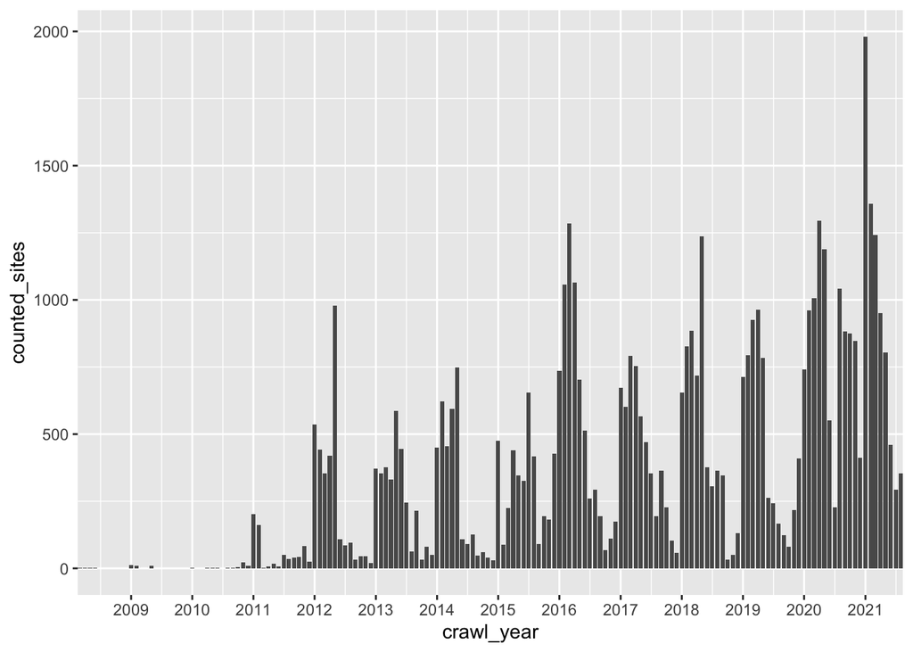

```r
df_graphic_month <- df_snippet_info %>%
  filter(site %in% df_domains_snippets$site) %>%
  mutate(month = month(crawl_date),
         fake_date = paste(year, month, "01", sep = "-") %>% as_date(.)
         ) %>%
  select(year, month, fake_date, site, sha1) %>%
  distinct() %>% #View()
  group_by(fake_date) %>%
  summarise(counted_sites = n()) #%>%

df_graphic_month %>%  ggplot(aes(x = fake_date, y = counted_sites)) +
  geom_bar(stat = "identity") +
  scale_x_date(date_breaks = "1 year", expand = c(0, NA), date_labels = "%Y", name = "crawl_year")
```

```r
  # facet_wrap(~site, ncol = 3)
```